# Comparison of donors and recipients in the St Louis and the Cryostem cohorts

Helena

23/04/2020

# CyTOF data

I can re-use the St Louis table that contained, for every patient, the percentage of cells in the 40 metaclusters, as well as the percentage of cells that were positive for the different functional markers:

I also extract clinical information on these patients (the recipients age, gender compatibility, the CMV status of donors and recipients, ...)

```
## [1] "0"
```

```
## [1] "1"
```

```
##    Id.Cryostem.R              GROUP GENDER        DOG TIMEPPOINT gender_comp
## 1          R2498       non_tolerant      F 2014-08-06         Y2          FF
## 3          R1503   primary_tolerant      M 2014-01-02         Y2          FM
## 6          R2032 secondary_tolerant      M 2014-04-22         Y2          MM
## 9          R1044   primary_tolerant      M 2013-09-12         Y2          MM
## 10         R2798 secondary_tolerant      F 2014-10-06         Y2          FF
## 11          R346       non_tolerant      F 2013-04-03         Y2          FF
##    age_recip cmv_comp
## 1      21794       01
## 3       8264       11
## 6      15701       00
## 9       7859       00
## 10     11254       11
## 11     17617       11
```

I also extract the table of CyTOF features in teh Cryostem cohort:

```r
mat_cryo <- readRDS("../data/cyto_national/compar_donors_recipients/mat_pheno_funct_all_patients.RDS")
```

And the clinical information for the Cryostem cohort:

```
## [1] 1
```

```
## [1] 1
```

```
##    Gender   HOSPITAL DATEOFCYTOFEXPERIMENT              group gender_comp
## 1       F CHU Angers            15.09.2017       non_tolerant          MF
## 10      F CHU Angers            21.09.2017   primary_tolerant          FF
## 11      F CHU Angers            21.09.2017   primary_tolerant          FF
## 12      M CHU Angers            21.09.2017   primary_tolerant          MM
## 13      F CHU Angers            21.09.2017       non_tolerant          MF
## 14      F CHU Angers            21.09.2017 secondary_tolerant          FF
##    age_recip cmv_comp
## 1      19529       11
## 10     16936       11
## 11     12009       00
## 12     22713      0NA
## 13     17236       00
## 14     12793       00
```

## Comparison of primary tolerant donors vs recipients

```
## [1] "112 CyTOF features varied significantly between donors and recipients in the Cryostem cohort, with a pvalue threshold of 0.05"
```

```r
# setting the parameters: what you can expect in case of independent tests
# in terms of FPs in one cohort and overlap.
# caveat: the tests are not independent, but I would expect similar results

ntests <- ncol(mat_louis_tmp)
FP <- c(0.05,0.10,0.15,0.20)
it <- 10000

out.05.coh1 <- matrix(NA,ntests,it)
out.05.coh2 <- matrix(NA,ntests,it)

out.10.coh1 <- matrix(NA,ntests,it)
out.10.coh2 <- matrix(NA,ntests,it)

out.15.coh1 <- matrix(NA,ntests,it)
out.15.coh2 <- matrix(NA,ntests,it)

out.20.coh1 <- matrix(NA,ntests,it)
out.20.coh2 <- matrix(NA,ntests,it)

set.seed(123)
for(i in (1:it)){
  out.05.coh1[,i] <- rbinom(ntests,1,FP[1])
  out.05.coh2[,i] <- rbinom(ntests,1,FP[1])
  out.10.coh1[,i] <- rbinom(ntests,1,FP[2])
  out.10.coh2[,i] <- rbinom(ntests,1,FP[2])
  out.15.coh1[,i] <- rbinom(ntests,1,FP[3])
  out.15.coh2[,i] <- rbinom(ntests,1,FP[3])
  out.20.coh1[,i] <- rbinom(ntests,1,FP[4])
  out.20.coh2[,i] <- rbinom(ntests,1,FP[4])
}

nFP.05.coh1 <- colSums(out.05.coh1)
hist(nFP.05.coh1)
nFP.05.coh2 <- colSums(out.05.coh2)
hist(nFP.05.coh2)
nFP.10.coh1 <- colSums(out.10.coh1)
hist(nFP.10.coh1)
nFP.10.coh2 <- colSums(out.10.coh2)
hist(nFP.10.coh2)
nFP.15.coh1 <- colSums(out.15.coh1)
hist(nFP.15.coh1)
nFP.15.coh2 <- colSums(out.15.coh2)
hist(nFP.15.coh2)
nFP.20.coh1 <- colSums(out.20.coh1)
hist(nFP.20.coh1)
nFP.20.coh2 <- colSums(out.20.coh2)
hist(nFP.20.coh2)

in.both.05 <- (out.05.coh1+out.05.coh2)>1
overlap.nFP.05 <- colSums(in.both.05)
hist(overlap.nFP.05)

in.both.10 <- (out.10.coh1+out.10.coh2)>1
overlap.nFP.10 <- colSums(in.both.10)
hist(overlap.nFP.10)

in.both.15 <- (out.15.coh1+out.15.coh2)>1
overlap.nFP.15 <- colSums(in.both.15)
hist(overlap.nFP.15)

in.both.20 <- (out.20.coh1+out.20.coh2)>1
overlap.nFP.20 <- colSums(in.both.20)
hist(overlap.nFP.20)
```

```r
###################
# permutation test:
###################

# with the amount of uncorrected positive tests, what are the odds of overlap?
ntests <- 7879
pos.coh1 <- 1202
pos.coh2 <- 3456
coh1 <- rep(0,ntests)
coh2 <- coh1
coh1[1:pos.coh1] <-1
sum(coh1)
coh2[1:pos.coh2] <- 1
sum(coh2)

it <- 10000
perm.coh1 <- matrix(NA,ntests,it)
perm.coh2 <- matrix(NA,ntests,it)

set.seed(123)
for(i in (1:it)){
  perm.coh1[,i] <- sample(coh1)
  perm.coh2[,i] <- sample(coh2)
}


in.both <- (perm.coh1+perm.coh2)>1
overlap <- colSums(in.both)
hist(overlap)
```

Because we are selecting features in the St Louis cohort irrespective of the adjusted pvalue, it can happen that the behaviour of the features in donors versus recipients are not matching in both cohorts.

Therefore, I apply a second filtering by computing the median in donors and recipients in each cohort and by checking that the features have the same behaviour in the two cohorts:

```r
mat_DR_louis <- readRDS("../data/cyto/compar_donors_recipients/mat_pheno_funct_donors_and_recipients.RDS") %>%
  magrittr::set_colnames(make.names(colnames(.))) %>%
  rownames_to_column("rn") %>%
  dplyr::filter(group == "primary_tolerant") %>%
  column_to_rownames("rn")
mat_DR_cryo <- readRDS("../data/cyto_national/compar_donors_recipients/mat_pheno_funct_donors_and_recipients.RDS") %>%
  magrittr::set_colnames(make.names(colnames(.))) %>%
  rownames_to_column("rn") %>%
  dplyr::filter(group == "primary_tolerant") %>%
  column_to_rownames("rn")

over2 <- data.frame(t(rep(0, 5))) %>%
  magrittr::set_colnames(c("variable", "adj_pvalue_St_Louis", "adj_pvalue_Cryostem", "median_Louis", "median_Cryo"))

for(i in 1:nrow(over)){
  tmp_l <- mat_DR_louis[over[i,"variable"]] %>%
    mutate(type = ifelse(grepl("D", rownames(mat_DR_louis)), "D", "R")) %>%
    group_by(type) %>%
    summarise_all(median)

  tmp_c <- mat_DR_cryo[over[i,"variable"]] %>%
    mutate(type = ifelse(grepl("D", rownames(mat_DR_cryo)), "D", "R")) %>%
    group_by(type) %>%
    summarise_all(median)

  if(tmp_l[1,2] >= tmp_l[2,2] && tmp_c[1,2] >= tmp_c[2,2]){
    over2 <- rbind(over2, over[i,])
  }
}

over2 <- over2[-1,]

under2 <- data.frame(t(rep(0, 5))) %>%
  magrittr::set_colnames(c("variable", "adj_pvalue_St_Louis", "adj_pvalue_Cryostem", "median_Louis", "median_Cryo"))

for(i in 1:nrow(under)){
  tmp_l <- mat_DR_louis[under[i,"variable"]] %>%
    mutate(type = ifelse(grepl("D", rownames(mat_DR_louis)), "D", "R")) %>%
    group_by(type) %>%
    summarise_all(median)

  tmp_c <- mat_DR_cryo[under[i,"variable"]] %>%
    mutate(type = ifelse(grepl("D", rownames(mat_DR_cryo)), "D", "R")) %>%
    group_by(type) %>%
    summarise_all(median)

  if(tmp_l[1,2] <= tmp_l[2,2] && tmp_c[1,2] <= tmp_c[2,2]){
    under2 <- rbind(under2, under[i,])
  }
}

under2 <- under2[-1,]

print(paste0(nrow(over2),
             " variables were over-expressed in the donors compared to the recipients, and ",
             nrow(under2),
             " variables were under-expressed in the donors compared to the recipients"))
```

```
## [1] "4 variables were over-expressed in the donors compared to the recipients, and 5 variables were under-expressed in the donors compared to the recipients"
```

```r
write.xlsx(over2, "../data/cyto/compar_donors_recipients/cytof_overexpressed_in_primary_donors.xlsx")
write.xlsx(under2, "../data/cyto/compar_donors_recipients/cytof_underexpressed_in_primary_donors.xlsx")
```

We can see how these different variables were correlated:

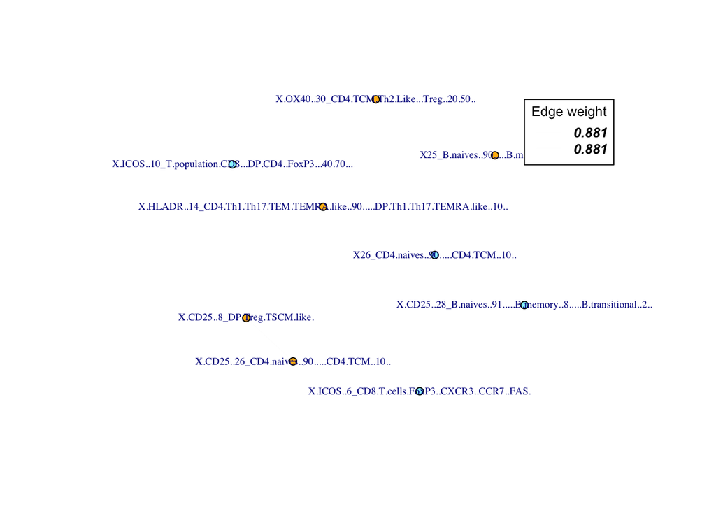

```
## IGRAPH 49b10a0 UN-- 9 1 --
## + attr: name (v/c), value (e/n)
## + edge from 49b10a0 (vertex names):
## [1] X.CD25..26_CD4.naives..90.....CD4.TCM..10..--X.CD25..8_DP.Treg.TSCM.like.
```

And save the tables of D-R values for the genes that were selected, in both cohorts:

```r
write.xlsx(data_2use, "../data/cyto/compar_donors_recipients/primary_sel.xlsx", row.names = TRUE)
direction <- c(rep("cadetblue1", nrow(over2)),
               rep("darkgoldenrod1", nrow(under2)))
saveRDS(direction, "../data/cyto/compar_donors_recipients/direction_features_primary_sel.RDS")


data_cryo <- mat_cryo %>%
  rownames_to_column("rn") %>%
  dplyr::filter(group == "primary_tolerant") %>%
  select(c(colnames(data_2use), "rn")) %>%
  column_to_rownames("rn")

write.xlsx(data_cryo, "../data/cyto_national/compar_donors_recipients/primary_sel.xlsx", row.names = TRUE)
```

### PCA

We can use the features that we just extracted as significantly differentially expressed in the primary tolerant donors and recipients to build a PCA:

```r
mat_DR_louis <- readRDS("../data/cyto/compar_donors_recipients/mat_pheno_funct_donors_and_recipients.RDS")
```

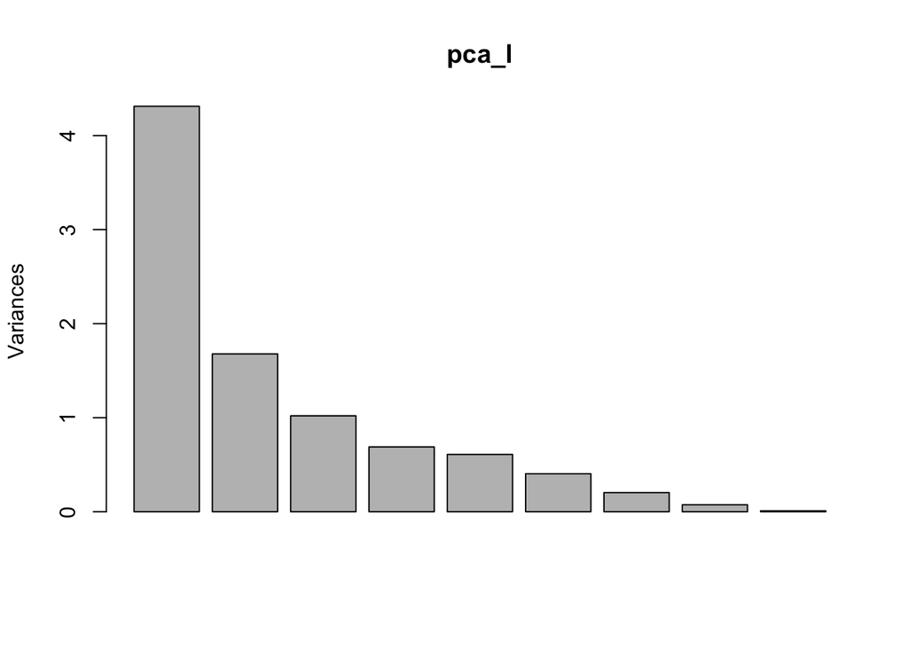

The features that we selected allow us to separate nicely the donors from the recipients along the first principal component:

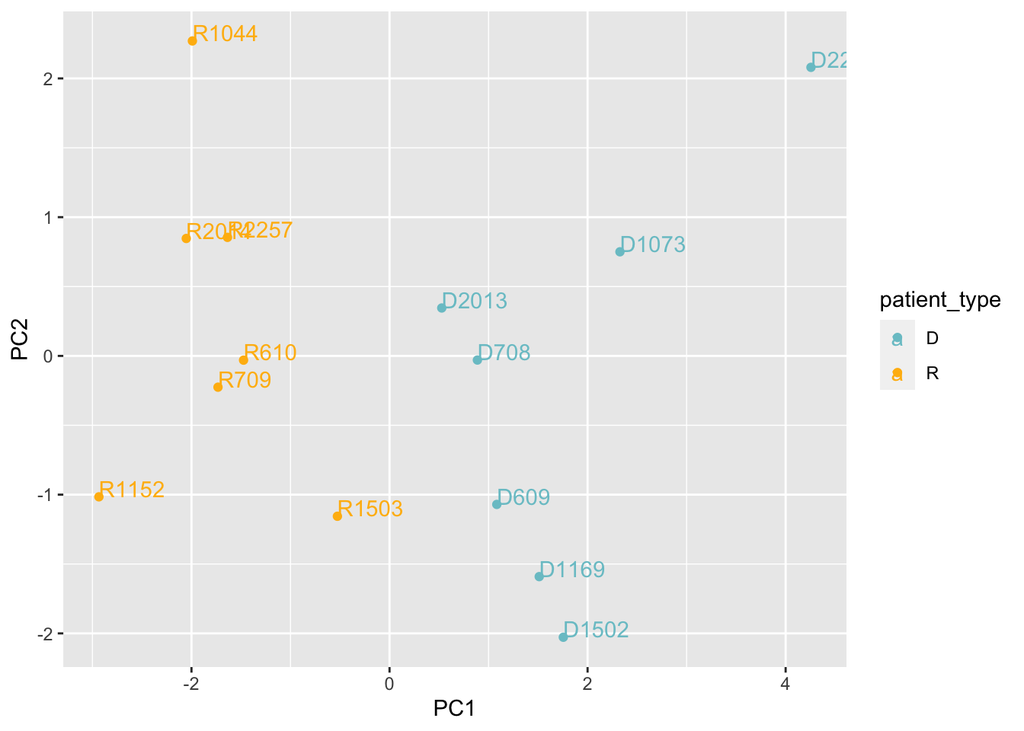

```r
mat4pca <- mat_2use %>%
  mutate(PC1 = pca_l$x[,1],
         PC2 = pca_l$x[,2])

ggplot(mat4pca, aes(x = PC1, y = PC2, col = patient_type), label = rn) +
  geom_point() +
  geom_text(aes(label=rn),hjust=0, vjust=0) +
  scale_color_manual(values = c("cadetblue3", "darkgoldenrod1"))
```

We can map the Cryostem primary tolerant patients on this same PCA:

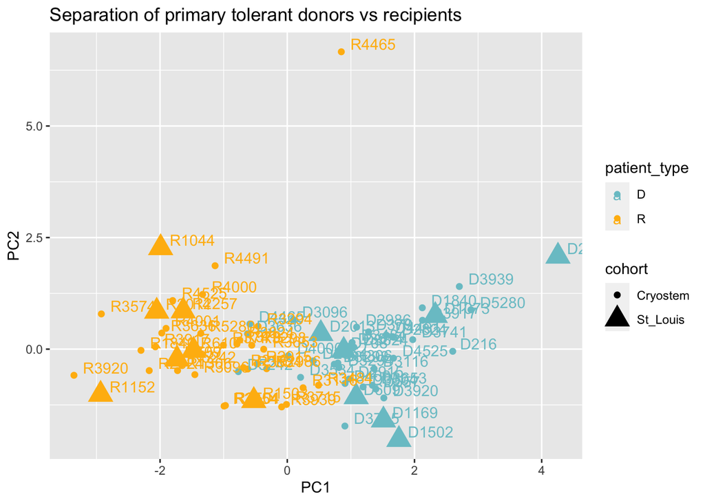

Write St Louis and Cryostem tables in excel files:

```r
matl <- mat_2use %>%
  column_to_rownames("rn")

matc <- mat_2use_cryo %>%
  column_to_rownames("rn")

write.xlsx(matl, "../data/cyto/compar_donors_recipients/mat_DR_primary_St_Louis.xlsx", row.names = TRUE)
write.xlsx(matc, "../data/cyto_national/compar_donors_recipients/mat_DR_primary_Cryostem.xlsx", row.names = TRUE)
```

## Comparison of secondary tolerant donors vs recipients

```
## [1] "4 CyTOF features varied significantly between donors and recipients in the Cryostem cohort, with a pvalue threshold of 0.05"
```

```
## [1] "No features had the same behaviour in both cohorts."
```

# Metabolomics data

I can re-use the St Louis table that contained, for every patient, the amount of every metabolite:

I also extract clinical information on these patients (the recipients age, gender compatibility, the CMV status of donors and recipients, ...)

```
## [1] "0"
```

```
## [1] "1"
```

```
##   Id.Cryostem.R              GROUP GENDER        DOG TIMEPPOINT gender_comp
## 1         R2498       non_tolerant      F 2014-08-06         Y2          FF
## 2          R385       non_tolerant      M 2013-05-02         Y2          FM
## 3         R1503   primary_tolerant      M 2014-01-02         Y2          FM
## 6         R2032 secondary_tolerant      M 2014-04-22         Y2          MM
## 7          R370 secondary_tolerant      M 2013-04-23         Y2          MM
## 9         R1044   primary_tolerant      M 2013-09-12         Y2          MM
##   age_recip cmv_comp
## 1     21794       01
## 2     21687      NA1
## 3      8264       11
## 6     15701       00
## 7      6219       00
## 9      7859       00
```

```r
mat_cryo <- readRDS("../data/metabo_national/compar_donors_recipients/mat_all_patients.RDS")
```

And the clinical information for the Cryostem cohort:

```
## [1] 1
```

```
## [1] 1
```

```
##    Gender   HOSPITAL DATEOFCYTOFEXPERIMENT              group gender_comp
## 1       F CHU Angers            15.09.2017       non_tolerant          MF
## 10      F CHU Angers            21.09.2017   primary_tolerant          FF
## 11      F CHU Angers            21.09.2017   primary_tolerant          FF
## 12      M CHU Angers            21.09.2017   primary_tolerant          MM
## 13      F CHU Angers            21.09.2017       non_tolerant          MF
## 14      F CHU Angers            21.09.2017 secondary_tolerant          FF
##    age_recip cmv_comp
## 1      19529       11
## 10     16936       11
## 11     12009       00
## 12     22713      0NA
## 13     17236       00
## 14     12793       00
```

## Comparison of primary tolerant donors vs recipients

[output not shown]

```
## [1] "0 metabolites varied significantly between donors and recipients in the Cryostem cohort, with a pvalue threshold of 0.05"
```

## Comparison of secondary tolerant donors vs recipients

```
## [1] "0 metabolites varied significantly between donors and recipients in the Cryostem cohort, with a pvalue threshold of 0.05"
```

# Transcriptomics data

I can re-use the St Louis table that contained, for every patient, the amount of every gene:

I also extract clinical information on these patients (the recipients age, gender compatibility, the CMV status of donors and recipients, ...)

```
## [1] "0"
```

```
## [1] "1"
```

```
##    Id.Cryostem.R              GROUP GENDER        DOG TIMEPPOINT gender_comp
## 3          R1503   primary_tolerant      M 2014-01-02         Y2          FM
## 6          R2032 secondary_tolerant      M 2014-04-22         Y2          MM
## 7           R370 secondary_tolerant      M 2013-04-23         Y2          MM
## 9          R1044   primary_tolerant      M 2013-09-12         Y2          MM
## 10         R2798 secondary_tolerant      F 2014-10-06         Y2          FF
## 11          R346       non_tolerant      F 2013-04-03         Y2          FF
##    age_recip cmv_comp
## 3       8264       11
## 6      15701       00
## 7       6219       00
## 9       7859       00
## 10     11254       11
## 11     17617       11
```

```r
mat_cryo <- readRDS("../data/RNA_seq_national/compar_donors_recipients/mat_all_patients.RDS")
```

And the clinical information for the Cryostem cohort:

```
## [1] 1
```

```
## [1] 1
```

```
##    Gender   HOSPITAL DATEOFCYTOFEXPERIMENT              group gender_comp
## 1       F CHU Angers            15.09.2017       non_tolerant          MF
## 10      F CHU Angers            21.09.2017   primary_tolerant          FF
## 11      F CHU Angers            21.09.2017   primary_tolerant          FF
## 12      M CHU Angers            21.09.2017   primary_tolerant          MM
## 13      F CHU Angers            21.09.2017       non_tolerant          MF
## 14      F CHU Angers            21.09.2017 secondary_tolerant          FF
##    age_recip cmv_comp
## 1      19529       11
## 10     16936       11
## 11     12009       00
## 12     22713      0NA
## 13     17236       00
## 14     12793       00
```

## Comparison of primary tolerant donors vs recipients

[output not shown]

Because we are selecting features in the St Louis cohort irrespective of the adjusted pvalue, it can happen that the behaviour of the features in donors versus recipients are not matching in both cohorts.

Therefore, I apply a second filtering by computing the median in donors and recipients in each cohort and by checking that the features have the same behaviour in the two cohorts:

```r
mat_DR_louis <- readRDS("../data/RNAseq/compar_donors_recipients/mat_pheno_funct_donors_and_recipients.RDS") %>%
  magrittr::set_colnames(make.names(colnames(.))) %>%
  magrittr::set_colnames(paste0("subst_", colnames(.))) %>%
  rownames_to_column("rn") %>%
  dplyr::filter(subst_GROUP == "primary_tolerant") %>%
  column_to_rownames("rn")
mat_DR_cryo <- readRDS("../data/RNA_seq_national/compar_donors_recipients/mat_pheno_funct_donors_and_recipients.RDS") %>%
  magrittr::set_colnames(make.names(colnames(.))) %>%
  magrittr::set_colnames(paste0("subst_", colnames(.))) %>%
  rownames_to_column("rn") %>%
  dplyr::filter(subst_GROUP == "primary_tolerant") %>%
  column_to_rownames("rn")

over2 <- data.frame(t(rep(0, 7))) %>%
  magrittr::set_colnames(c("variable", "pvalue_St_Louis", "pvalue_Cryostem", "adj_pvalue_St_Louis", "adj_pvalue_Cryostem", "median_Louis", "median_Cryo"))

for(i in 1:nrow(over)){
  tmp_l <- mat_DR_louis[over[i,"variable"]] %>%
    mutate(type = ifelse(grepl("D", rownames(mat_DR_louis)), "D", "R")) %>%
    dplyr::group_by(type) %>%
    summarise_all(median)

  tmp_c <- mat_DR_cryo[over[i,"variable"]] %>%
    mutate(type = ifelse(grepl("D", rownames(mat_DR_cryo)), "D", "R")) %>%
    dplyr::group_by(type) %>%
    summarise_all(median)

  if(tmp_l[1,2] >= tmp_l[2,2] && tmp_c[1,2] >= tmp_c[2,2]){
    over2 <- rbind(over2, over[i,])
  }
}

over2 <- over2[-1,]

under2 <- data.frame(t(rep(0, 7))) %>%
  magrittr::set_colnames(c("variable", "pvalue_St_Louis", "pvalue_Cryostem", "adj_pvalue_St_Louis", "adj_pvalue_Cryostem", "median_Louis", "median_Cryo"))

for(i in 1:nrow(under)){
  tmp_l <- mat_DR_louis[under[i,"variable"]] %>%
    mutate(type = ifelse(grepl("D", rownames(mat_DR_louis)), "D", "R")) %>%
    group_by(type) %>%
    summarise_all(median)

  tmp_c <- mat_DR_cryo[under[i,"variable"]] %>%
    mutate(type = ifelse(grepl("D", rownames(mat_DR_cryo)), "D", "R")) %>%
    group_by(type) %>%
    summarise_all(median)

  if(tmp_l[1,2] <= tmp_l[2,2] && tmp_c[1,2] <= tmp_c[2,2]){
    under2 <- rbind(under2, under[i,])
  }
}

under2 <- under2[-1,]

print(paste0(nrow(over2),
             " variables were over-expressed in the donors compared to the recipients, and ",
             nrow(under2),
             " variables were under-expressed in the donors compared to the recipients"))
```

```
## [1] "430 variables were over-expressed in the donors compared to the recipients, and 34 variables were under-expressed in the donors compared to the recipients"
```

```r
write.xlsx(over2, "../data/RNAseq/compar_donors_recipients/rnaseq_overexpressed_in_primary_donors.xlsx")
write.xlsx(under2, "../data/RNAseq/compar_donors_recipients/rnaseq_underexpressed_in_primary_donors.xlsx")
```

I save these features and compute their pvalues/ fold changes:

```r
annot_genes <- as.data.frame(c(over2$variable, under2$variable))
colnames(annot_genes) <- "Gene"

# Compute the FC and pvalues:
TS <- ifelse(grepl("D", rownames(mat_DR_louis)), "D", "R")

TS <- factor(TS, levels=unique(TS))
design <- model.matrix(~0+TS)
colnames(design) <- levels(TS)
#design
fit <- limma::lmFit(t(mat_DR_louis[,c(over2$variable, under2$variable)]), design)

#### Create contrast matrix
cont.matrix <- limma::makeContrasts(group1=D-R,
                             group2=R-D,
                             levels=design)
#cont.matrix
fit2 = limma::contrasts.fit(fit, cont.matrix)

#### Moderate T-test with 'shrunken' se
fit.eb <- limma::eBayes(fit2)


allGenesGroup1<-limma::topTable(fit.eb, adjust="BH", sort.by="P",number=Inf, coef=1)

getDEgenes<-function(expMatrix, pValCutOff, logFCcutOff){
  topgenes<-expMatrix[expMatrix$adj.P.Val<pValCutOff,]
  genes_up<-topgenes[topgenes$logFC>logFCcutOff,]
  genes_down<-topgenes[topgenes$logFC< -logFCcutOff,]
  ##Sort genes on logFC
  genes_up<-genes_up[order(genes_up$logFC, decreasing=TRUE),]
  genes_down<-genes_down[order(genes_down$logFC, decreasing=TRUE),]
  genes_de_sorted<-rbind(genes_up, genes_down)

  return(genes_de_sorted)
}

DEgenesGroup1<-getDEgenes(allGenesGroup1,1,0)

#length(which(selected_genes_qt[sel_common] %in% rownames(DEgenesGroup1)))

# add them to the table

DEgenesGroup1 <- DEgenesGroup1[as.character(annot_genes$Gene),]
annot_genes <- cbind(annot_genes, DEgenesGroup1)

write.xlsx(annot_genes, "../data/RNAseq/compar_donors_recipients/FC_464genes_louis.xlsx")
```

```r
# setting the parameters: what you can expect in case of independent tests
# in terms of FPs in one cohort and overlap.
# caveat: the tests are not independent, but I would expect similar results

ntests <- ncol(mat_louis_tmp)
FP <- c(0.05,0.10,0.15,0.20)
it <- 10000

out.05.coh1 <- matrix(NA,ntests,it)
out.05.coh2 <- matrix(NA,ntests,it)

out.10.coh1 <- matrix(NA,ntests,it)
out.10.coh2 <- matrix(NA,ntests,it)

out.15.coh1 <- matrix(NA,ntests,it)
out.15.coh2 <- matrix(NA,ntests,it)

out.20.coh1 <- matrix(NA,ntests,it)
out.20.coh2 <- matrix(NA,ntests,it)

set.seed(123)
for(i in (1:it)){
  out.05.coh1[,i] <- rbinom(ntests,1,FP[1])
  out.05.coh2[,i] <- rbinom(ntests,1,FP[1])
  out.10.coh1[,i] <- rbinom(ntests,1,FP[2])
  out.10.coh2[,i] <- rbinom(ntests,1,FP[2])
  out.15.coh1[,i] <- rbinom(ntests,1,FP[3])
  out.15.coh2[,i] <- rbinom(ntests,1,FP[3])
  out.20.coh1[,i] <- rbinom(ntests,1,FP[4])
  out.20.coh2[,i] <- rbinom(ntests,1,FP[4])
}

nFP.05.coh1 <- colSums(out.05.coh1)
hist(nFP.05.coh1)
nFP.05.coh2 <- colSums(out.05.coh2)
hist(nFP.05.coh2)
nFP.10.coh1 <- colSums(out.10.coh1)
hist(nFP.10.coh1)
nFP.10.coh2 <- colSums(out.10.coh2)
hist(nFP.10.coh2)
nFP.15.coh1 <- colSums(out.15.coh1)
hist(nFP.15.coh1)
nFP.15.coh2 <- colSums(out.15.coh2)
hist(nFP.15.coh2)
nFP.20.coh1 <- colSums(out.20.coh1)
hist(nFP.20.coh1)
nFP.20.coh2 <- colSums(out.20.coh2)
hist(nFP.20.coh2)

in.both.05 <- (out.05.coh1+out.05.coh2)>1
overlap.nFP.05 <- colSums(in.both.05)
hist(overlap.nFP.05)

in.both.10 <- (out.10.coh1+out.10.coh2)>1
overlap.nFP.10 <- colSums(in.both.10)
hist(overlap.nFP.10)

in.both.15 <- (out.15.coh1+out.15.coh2)>1
overlap.nFP.15 <- colSums(in.both.15)
hist(overlap.nFP.15)

in.both.20 <- (out.20.coh1+out.20.coh2)>1
overlap.nFP.20 <- colSums(in.both.20)
hist(overlap.nFP.20)
```

We can see how these different variables were correlated:

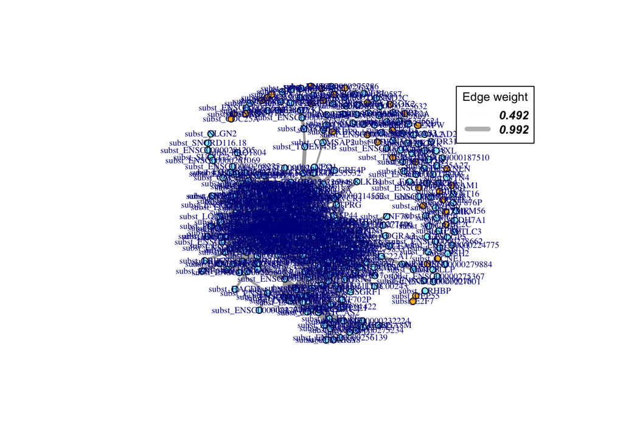

Save these correlations:

```r
gr_components <- decompose(gr, mode = "strong", max.comps = NA,
                             min.vertices = 0)
comp_sizes <- sapply(gr_components, diameter)

# Generate a new annotated excel table
annot_genes <- as.data.frame(names(V(gr)))

for( i in which(comp_sizes != 0)){
  vertex_names <- vertex_attr(gr_components[[i]], index = V(gr_components[[i]]))[[1]]
  v_names <- c(vertex_names, rep(0, nrow(annot_genes) - length(vertex_names)))
  annot_genes <- cbind(annot_genes, v_names)
}

write.xlsx(annot_genes, file = "../data/RNAseq/compar_donors_recipients/correlated_components.xlsx")
```

And save the tables of D-R values for the genes that were selected, in both cohorts:

```r
write.xlsx(data_2use, "../data/RNAseq/compar_donors_recipients/primary_sel.xlsx", row.names = TRUE)

direction <- c(rep("cadetblue1", nrow(over2)),
               rep("darkgoldenrod1", nrow(under2)))
saveRDS(direction, "../data/RNAseq/compar_donors_recipients/direction_features_primary_sel.RDS")

data_cryo <- mat_cryo %>%
  rownames_to_column("rn") %>%
  dplyr::filter(group == "primary_tolerant") %>%
  select(c(colnames(data_2use), "rn")) %>%
  column_to_rownames("rn")

write.xlsx(data_cryo, "../data/RNA_seq_national/compar_donors_recipients/primary_sel.xlsx", row.names = TRUE)
```

### PCA

We can use the features that we just extracted as significantly differentially expressed in the primary tolerant donors and recipients to build a PCA:

```r
mat_DR_louis <- readRDS("../data/RNAseq/compar_donors_recipients/mat_pheno_funct_donors_and_recipients.RDS")
```

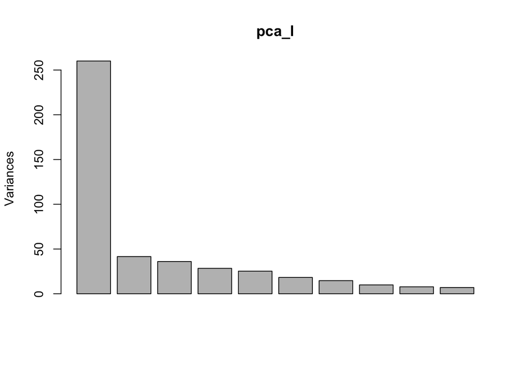

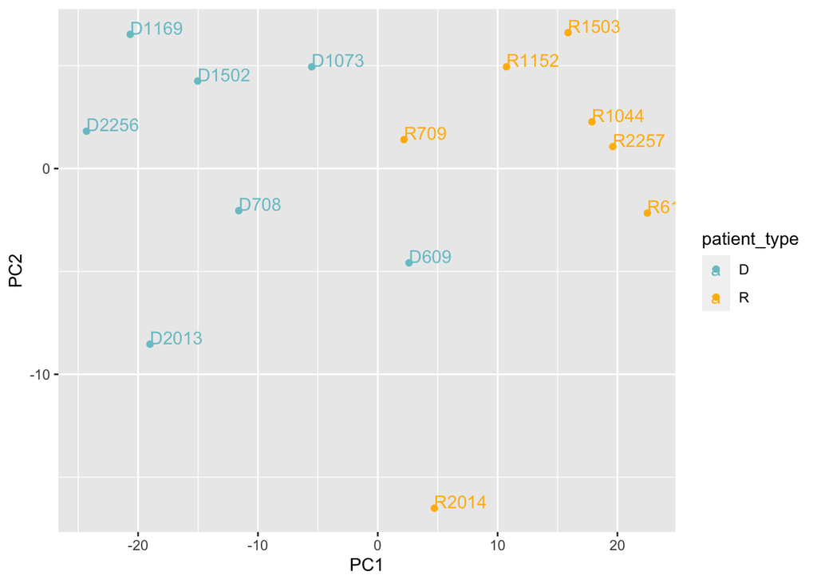

```r
mat4pca <- mat_2use %>%
  mutate(PC1 = pca_l$x[,1],
         PC2 = pca_l$x[,2])

ggplot(mat4pca, aes(x = PC1, y = PC2, col = patient_type), label = subst_rn) +
  geom_point() +
  geom_text(aes(label=subst_rn),hjust=0, vjust=0) +
  scale_color_manual(values = c("cadetblue3", "darkgoldenrod1"))
```

We can map the Cryostem primary tolerant patients on this same PCA:

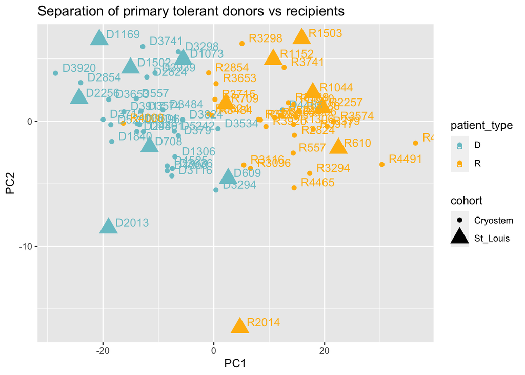

Write St Louis and Cryostem tables in excel files:

```r
matl <- mat_2use %>%
  column_to_rownames("subst_rn")

matc <- mat_2use_cryo %>%
  column_to_rownames("subst_rn")

write.xlsx(matl, "../data/RNAseq/compar_donors_recipients/mat_DR_primary_St_Louis.xlsx", row.names = TRUE)
write.xlsx(matc, "../data/RNA_seq_national/compar_donors_recipients/mat_DR_primary_Cryostem.xlsx", row.names = TRUE)
```

Compute "paired FCs"

```r
matl <- read.xlsx("../data/RNAseq/compar_donors_recipients/mat_DR_primary_St_Louis.xlsx", rowNames = TRUE)


FC_louis <- as.data.frame(colnames(matl)[1:(ncol(matl)-1)]) %>%
  mutate(paired_FC = rep(0, ncol(matl)-1)) %>%
  magrittr::set_colnames(c("gene", "paired_FC"))

for(i in 1:nrow(FC_louis)){
  r <- matl[,as.character(FC_louis$gene[i])]
  nb_couples <- length(r)/2
  s <- 0
  for(j in 1:nb_couples){
    if(r[j] < 0 || r[j + nb_couples] < 0){
      v1 <- r[j] - min(r[j], r[j + nb_couples]) +0.1
      v2 <- r[j + nb_couples] - min(r[j], r[j + nb_couples]) +0.1
    } else {
      v1 <- r[j]
      v2 <- r[j + nb_couples]
    }
    print(v1/v2)
    s <- s + (v1 / v2)
  }
  s <- s/nb_couples
  FC_louis$paired_FC[i] <- s
}
```

```
## [1] 21.60528
## [1] 16.29173
## [1] 33.87176
## [1] 0.1072627
## [1] 32.06717
## [1] 16.27492
## [1] 23.5209
## [1] 1.157528
## [1] 1.119252
## [1] 1.443845
## [1] 1.44071
## [1] 2.389945
## [1] 1.257105
## [1] 1.338018
## [1] 1.879266
```

[output cut: 3233 more lines]

```r
FC_louis <- as.data.frame(colnames(matl)[1:(ncol(matl)-1)]) %>%
  mutate(FC = rep(0, ncol(matl)-1),
         logFC = rep(0, ncol(matl)-1)) %>%
  magrittr::set_colnames(c("gene", "FC", "logFC"))

for(i in 1:nrow(FC_louis)){
  r <- matl[,as.character(FC_louis$gene[i])]
  D <- median(r[which(matl$patient_type == "D")])
  R <- median(r[which(matl$patient_type == "R")])
  if(D < 0 || R < 0){
      v1 <- D - min(D, R) +0.1
      v2 <- R - min(D, R) +0.1
    } else {
      v1 <- D
      v2 <- R
    }
  FC_louis$FC[i] <- v1/v2
  FC_louis$logFC[i] <- log(v1/v2)
}

write.xlsx(FC_louis, "../data/RNAseq/compar_donors_recipients/FCs_louis.xlsx")

matc <- read.xlsx("../data/RNA_seq_national/compar_donors_recipients/mat_DR_primary_Cryostem.xlsx", rowNames = TRUE)

FC_cryo <- as.data.frame(colnames(matc)[1:(ncol(matc)-1)]) %>%
  mutate(FC = rep(0, ncol(matc)-1),
         logFC = rep(0, ncol(matc)-1)) %>%
  magrittr::set_colnames(c("gene", "FC", "logFC"))

for(i in 1:nrow(FC_cryo)){
  r <- matc[,as.character(FC_cryo$gene[i])]
  D <- median(r[which(matc$patient_type == "D")])
  R <- median(r[which(matc$patient_type == "R")])
  if(D < 0 || R < 0){
      v1 <- D - min(D, R) +0.1
      v2 <- R - min(D, R) +0.1
    } else {
      v1 <- D
      v2 <- R
    }
  FC_cryo$FC[i] <- v1/v2
  FC_cryo$logFC[i] <- log(v1/v2)
}

write.xlsx(FC_cryo, "../data/RNAseq/compar_donors_recipients/FCs_cryo.xlsx")
```

## Comparison of secondary tolerant donors vs recipients

```
## [1] "719 genes varied significantly between donors and recipients in the Cryostem cohort, with a pvalue threshold of 0.05"
```

Because we are selecting features in the St Louis cohort irrespective of the adjusted pvalue, it can happen that the behaviour of the features in donors versus recipients are not matching in both cohorts.

Therefore, I apply a second filtering by computing the median in donors and recipients in each cohort and by checking that the features have the same behaviour in the two cohorts:

```r
mat_DR_louis <- readRDS("../data/RNAseq/compar_donors_recipients/mat_pheno_funct_donors_and_recipients.RDS") %>%
  magrittr::set_colnames(make.names(colnames(.))) %>%
  magrittr::set_colnames(paste0("subst_", colnames(.))) %>%
  rownames_to_column("rn") %>%
  dplyr::filter(subst_GROUP == "secondary_tolerant") %>%
  column_to_rownames("rn")
mat_DR_cryo <- readRDS("../data/RNA_seq_national/compar_donors_recipients/mat_pheno_funct_donors_and_recipients.RDS") %>%
  magrittr::set_colnames(make.names(colnames(.))) %>%
  magrittr::set_colnames(paste0("subst_", colnames(.))) %>%
  rownames_to_column("rn") %>%
  dplyr::filter(subst_GROUP == "secondary_tolerant") %>%
  column_to_rownames("rn")

over2 <- data.frame(t(rep(0, 5))) %>%
  magrittr::set_colnames(c("variable", "adj_pvalue_St_Louis", "adj_pvalue_Cryostem", "median_Louis", "median_Cryo"))

for(i in 1:nrow(over)){
  tmp_l <- mat_DR_louis[over[i,"variable"]] %>%
    mutate(type = ifelse(grepl("D", rownames(mat_DR_louis)), "D", "R")) %>%
    dplyr::group_by(type) %>%
    summarise_all(median)

  tmp_c <- mat_DR_cryo[over[i,"variable"]] %>%
    mutate(type = ifelse(grepl("D", rownames(mat_DR_cryo)), "D", "R")) %>%
    dplyr::group_by(type) %>%
    summarise_all(median)

  if(tmp_l[1,2] >= tmp_l[2,2] && tmp_c[1,2] >= tmp_c[2,2]){
    over2 <- rbind(over2, over[i,])
  }
}

over2 <- over2[-1,]

# under2 <- data.frame(t(rep(0, 5))) %>%
#   magrittr::set_colnames(c("variable", "adj_pvalue_St_Louis", "adj_pvalue_Cryostem", "median_Louis", "median_Cryo"))
#
# for(i in 1:nrow(under)){
#   tmp_l <- mat_DR_louis[under[i,"variable"]] %>%
#     mutate(type = ifelse(grepl("D", rownames(mat_DR_louis)), "D", "R")) %>%
#     group_by(type) %>%
#     summarise_all(median)
#
#   tmp_c <- mat_DR_cryo[under[i,"variable"]] %>%
#     mutate(type = ifelse(grepl("D", rownames(mat_DR_cryo)), "D", "R")) %>%
#     group_by(type) %>%
#     summarise_all(median)
#
#   if(tmp_l[1,2] <= tmp_l[2,2] && tmp_c[1,2] <= tmp_c[2,2]){
#     under2 <- rbind(under2, under[i,])
#   }
# }
#
# under2 <- under2[-1,]

print(paste0(nrow(over2),
             " variables were over-expressed in the donors compared to the recipients."))#", and ",
```

```
## [1] "1 variables were over-expressed in the donors compared to the recipients."
```

```r
             # nrow(under2),
             # " variables were under-expressed in the donors compared to the recipients"))


write.xlsx(over2, "../data/RNAseq/compar_donors_recipients/cytof_overexpressed_in_secondary_donors.xlsx")
#write.xlsx(under2, "../data/RNAseq/compar_donors_recipients/cytof_underexpressed_in_primary_donors.xlsx")
```

## CyTOF + Transcriptomics

```r
matl_cyto <- read.xlsx("../data/cyto/compar_donors_recipients/primary_sel.xlsx", rowNames = TRUE)
matl_transcripto <- read.xlsx("../data/RNAseq/compar_donors_recipients/primary_sel.xlsx", rowNames = TRUE)

colnames(matl_cyto) <- paste0("cyt_", colnames(matl_cyto))
colnames(matl_transcripto) <- paste0("rna_", colnames(matl_transcripto))

matc_cyto <- read.xlsx("../data/cyto_national/compar_donors_recipients/primary_sel.xlsx", rowNames = TRUE)
matc_transcripto <- read.xlsx("../data/RNA_seq_national/compar_donors_recipients/primary_sel.xlsx", rowNames = TRUE)

colnames(matc_cyto) <- paste0("cyt_", colnames(matc_cyto))
colnames(matc_transcripto) <- paste0("rna_", colnames(matc_transcripto))

if(all(rownames(matl_cyto) == rownames(matl_transcripto))){
  data_2use <- cbind(matl_cyto, matl_transcripto)
}

if(all(rownames(matc_cyto) == rownames(matc_transcripto))){
  merged <- cbind(matc_cyto, matc_transcripto)
  saveRDS(merged, "../data/cyto/compar_donors_recipients/Cryo_cytof_and_rna_primary.RDS")
} else {
  if(nrow(matc_cyto) > nrow(matc_transcripto)){
    matc_cyto <- matc_cyto[rownames(matc_transcripto),]
  } else {
    matc_transcripto <- matc_transcripto[rownames(matc_cyto),]
  }
  merged <- cbind(matc_cyto, matc_transcripto)
  saveRDS(merged, "../data/cyto/compar_donors_recipients/Cryo_cytof_and_rna_primary.RDS")
}
```

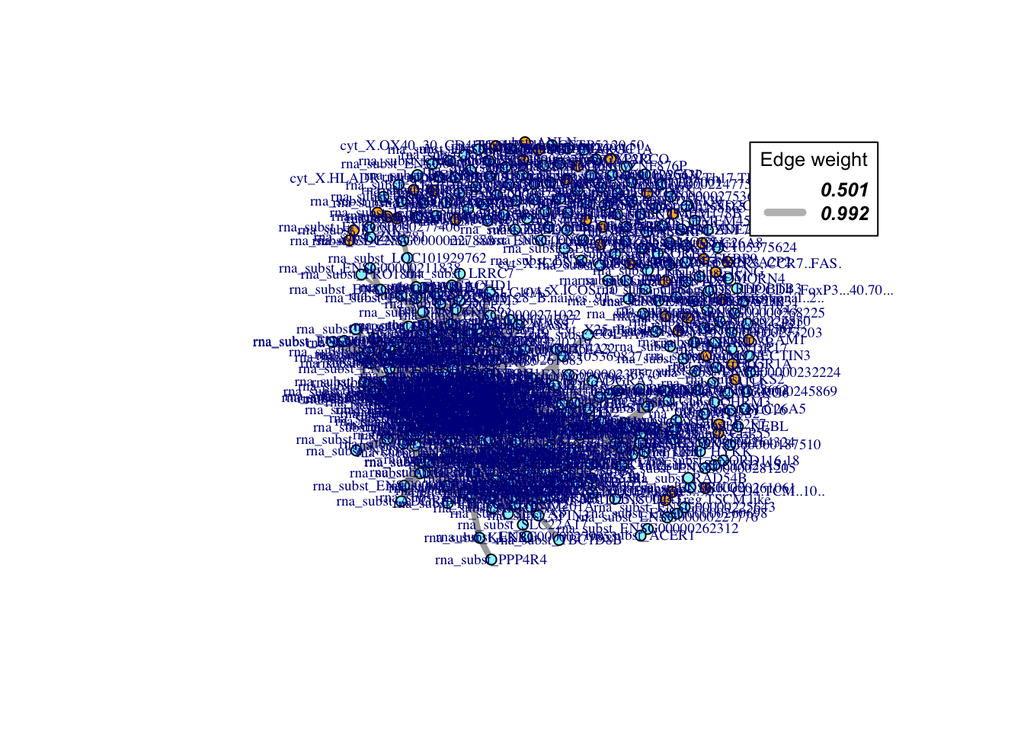

```r
dir1 <- readRDS("../data/cyto/compar_donors_recipients/direction_features_primary_sel.RDS")
dir2 <- readRDS("../data/RNAseq/compar_donors_recipients/direction_features_primary_sel.RDS")

gr <- plot_correlations2(ft_df = data_2use,
                  ft_file_other_cohort = "~/Documents/VIB/Projects/Integrative_Paris/Integrative/outputs/data/cyto/compar_donors_recipients/Cryo_cytof_and_rna_primary.RDS",
                  node_color = c(dir1, dir2),
                  pval_threshold = 0.01)
```

Save these correlations:

```r
gr_components <- decompose(gr, mode = "strong", max.comps = NA,
                             min.vertices = 0)
comp_sizes <- sapply(gr_components, diameter)

# Generate a new annotated excel table
annot_genes <- as.data.frame(names(V(gr)))

for( i in which(comp_sizes != 0)){
  vertex_names <- vertex_attr(gr_components[[i]], index = V(gr_components[[i]]))[[1]]
  v_names <- c(vertex_names, rep(0, nrow(annot_genes) - length(vertex_names)))
  annot_genes <- cbind(annot_genes, v_names)
}

write.xlsx(annot_genes, file = "../data/cyto/compar_donors_recipients/correlated_components_cyto_and_rna.xlsx")
```